# Introduction to Big Data for Social Science

Machine Learning Methods

Christoph Kern

## Setup

```r
# install.packages("tidyverse")
# install.packages("rpart")
# install.packages("partykit")
# install.packages("ranger")
# install.packages("caret")
# install.packages("pROC")
```

```r
library(tidyverse)
library(rpart)
library(partykit)
library(ranger)
library(caret)
library(pROC)
```

## Data

For this example, we (again) use the census income data set from the UCI ML repository. It contains “a set of reasonably clean records” from the 1994 Census database. The prediction task is to determine whether a person makes over 50K a year.

Source: https://archive.ics.uci.edu/ml/datasets/Census+Income

First, we load the data and assign variable names.

```r
census <- read.csv("census.data", header = FALSE, na.strings = " ?")
varnames <- read.delim("census.names", header = FALSE, skip = 95)
names(census) <- as.character(varnames$V1)
```

Next, we have to clean the factor levels.

```r
cln_levels <- function(x){
  levels(x) <- make.names(gsub(" ", "", levels(x)))
  x
}
census[, c(2,4,6,7,8,9,14)] <- lapply(census[, c(2,4,6,7,8,9,14)], cln_levels)
```

In addition, we drop cases with missing values and empty factor levels.

```r
census$capital_gain[census$capital_gain >= 99990] <- NA
census <- drop_na(census)
census <- droplevels(census)
```

We also exclude some variables that we won’t use in our models.

```r
census$fnlwgt <- NULL
census$education <- NULL
census$native_country <- NULL
```

Here we rename the factor levels of the outcome variable and print the frequencies of the outcome categories.

```r
levels(census$inc) <- c("under_50K", "over_50K")
summary(census$inc)
```

```
under_50K  over_50K
    22654      7360
```

## Train and test set

Next, we want to split the data into a training (80%) and a test (20%) part. We use `createDataPartition()` from `caret` for this task, which samples within the levels of the outcome variable when splitting the data (i.e. creates stratified splits).

```r
set.seed(92385)
inTrain <- createDataPartition(census$inc,
                               p = .8,
                               list = FALSE,
                               times = 1)
census_train <- census[inTrain,]
census_test <- census[-inTrain,]
```

## CART

As a first model, we grow a classification tree with `rpart`, which follows the CART idea. In this code example, tree size is controlled by the default options (see `?rpart`).

```r
tree1 <- rpart(inc ~ ., data = census_train,
               method = "class")
tree1
```

```
n= 24012

node), split, n, loss, yval, (yprob)
      * denotes terminal node

 1) root 24012 5888 under_50K (0.75478927 0.24521073)
   2) relationship=Not.in.family,Other.relative,Own.child,Unmarried 13047  903 under_50K (0.93078869 0.06921131)
     4) capital_gain< 7073.5 12816  680 under_50K (0.94694132 0.05305868) *
     5) capital_gain>=7073.5 231    8 over_50K (0.03463203 0.96536797) *
   3) relationship=Husband,Wife 10965 4985 under_50K (0.54537164 0.45462836)
     6) education_num< 12.5 7741 2628 under_50K (0.66050898 0.33949102)
      12) capital_gain< 5095.5 7350 2246 under_50K (0.69442177 0.30557823) *
      13) capital_gain>=5095.5 391    9 over_50K (0.02301790 0.97698210) *
     7) education_num>=12.5 3224  867 over_50K (0.26892060 0.73107940) *
```

Of course, trees are (usually) best represented by a plot. Here we use the `partykit` package to first convert the tree into the party format and then use `plot()` on the new object.

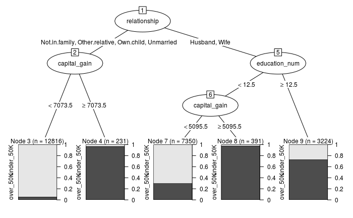

```r
party_tree1 <- as.party(tree1)
plot(party_tree1, gp = gpar(fontsize = 9))
```

Lets build a larger tree.

```r
tree2 <- rpart(inc ~ ., data = census_train,
               control = rpart.control(minsplit = 10, # minimal obs in a node
                                       minbucket = 3, # minimal obs in any terminal node
                                       cp = 0.0001, # min improvement through splitting
                                       maxdepth = 30 # maximum tree depth
                                       ))
```

This large tree is likely to overfit and might not generalize well to new data. Therefore, we use `printcp()` and `plotcp()` that help us to determine the best subtree. `Root node error` times `xerror` gives us the estimated test error for each subtree based on cross-validation.

```r
printcp(tree2)
```

```
Classification tree:
rpart(formula = inc ~ ., data = census_train, control = rpart.control(minsplit = 10,
    minbucket = 3, cp = 1e-04, maxdepth = 30))

Variables actually used in tree construction:
 [1] age            capital_gain   capital_loss   education_num  hours_per_week
 [6] marital_status occupation     race           relationship   sex
[11] workclass

Root node error: 5888/24012 = 0.24521

n= 24012

           CP nsplit rel error  xerror      xstd
1  0.12652853      0   1.00000 1.00000 0.0113222
```

[output cut: 44 more lines]

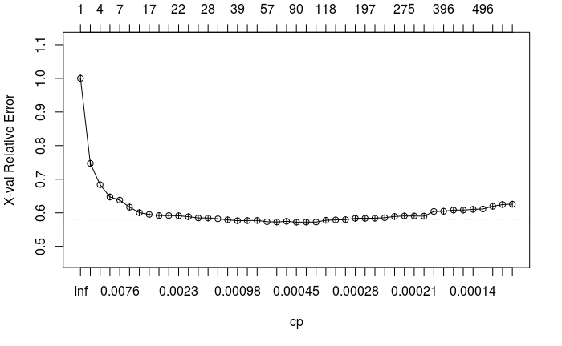

```r
plotcp(tree2)
```

On this basis, we want to choose the cp value that is associated with the smallest CV error. We could do this by hand or by using a few lines of code.

```r
minx <- which.min(tree2$cptable[,"xerror"])
mincp <- tree2$cptable[minx,"CP"]
mincp
```

```
[1] 0.0004245924
```

Now we can get the best subtree with the `prune()` function and save it as our final tree model.

```r
tree3 <- prune(tree2, cp = mincp)
```

## Random Forest

In order to build a random forest, we again use the `caret` package, which requires to first specify the evaluation method. In the following, we use 5-fold cross-validation.

```r
ctrl <- trainControl(method = "cv",
                     number = 5,
                     summaryFunction = twoClassSummary,
                     classProbs = TRUE,
                     verboseIter = TRUE)
```

We also need to specify a set of try-out values for model tuning. For random forest, we primarily have to care about `mtry`, i.e. the number of features to sample at each split point.

```r
ncols <- ncol(model.matrix(inc ~ ., data = census_train))
grid <- expand.grid(mtry = c(floor(sqrt(ncols))-1,
                              floor(sqrt(ncols)),
                              floor(sqrt(ncols))+1),
                    splitrule = "gini",
                    min.node.size = 10)
grid
```

| mtry | splitrule | min.node.size |
| --- | --- | --- |
| 5 | gini | 10 |
| 6 | gini | 10 |
| 7 | gini | 10 |

These objects can now be passed on to `train()`, along with the specification of the prediction method. For random forests, we use `ranger`.

```r
rf <- train(inc ~ .,
            data = census_train,
            method = "ranger",
            trControl = ctrl,
            tuneGrid = grid)
```

Calling the random forest object lists the results of the tuning process.

```r
rf
```

```
Random Forest

24012 samples
   11 predictors
    2 classes: 'under_50K', 'over_50K'

No pre-processing
Resampling: Cross-Validated (5 fold)
Summary of sample sizes: 19211, 19210, 19209, 19209, 19209
Resampling results across tuning parameters:

  mtry  ROC        Sens       Spec
  5     0.9170065  0.9417345  0.6102212
  6     0.9170412  0.9395276  0.6195621
  7     0.9165711  0.9379275  0.6253358

Tuning parameter 'splitrule' was held constant at a value of gini
Tuning
 parameter 'min.node.size' was held constant at a value of 10
ROC was used to select the optimal model using the largest value.
The final values used for the model were mtry = 6, splitrule = gini
 and min.node.size = 10.
```

With random forests, the individual trees of the ensemble typically look quite different. To get an idea of the components of the forest, `treeInfo()` can be used to print individual trees.

```r
treeInfo(rf$finalModel, tree = 1)[1:10,]
```

|  | nodeID | leftChild | rightChild | splitvarID | splitvarName | splitval | terminal | pred.under_50K | pred.over_50K |
| --- | --- | --- | --- | --- | --- | --- | --- | --- | --- |
| 1 | 0 | 1 | 2 | 29 | relationshipOwn.child | 0.5 | FALSE | NA | NA |
| 2 | 1 | 3 | 4 | 9 | marital_statusMarried.civ.spouse | 0.5 | FALSE | NA | NA |
| 3 | 2 | 5 | 6 | 38 | capital_loss | 2218.0 | FALSE | NA | NA |
| 4 | 3 | 7 | 8 | 36 | sex Male | 0.5 | FALSE | NA | NA |
| 5 | 4 | 9 | 10 | 19 | occupationMachine.op.inspct | 0.5 | FALSE | NA | NA |
| 6 | 5 | 11 | 12 | 0 | age | 42.5 | FALSE | NA | NA |
| 7 | 6 | NA | NA | NA | NA | NA | TRUE | 0.3333333 | 0.6666667 |
| 8 | 7 | 13 | 14 | 38 | capital_loss | 2248.0 | FALSE | NA | NA |
| 9 | 8 | 15 | 16 | 28 | relationshipOther.relative | 0.5 | FALSE | NA | NA |
| 10 | 9 | 17 | 18 | 39 | hours_per_week | 41.5 | FALSE | NA | NA |

```r
treeInfo(rf$finalModel, tree = 2)[1:10,]
```

|  | nodeID | leftChild | rightChild | splitvarID | splitvarName | splitval | terminal | pred.under_50K | pred.over_50K |
| --- | --- | --- | --- | --- | --- | --- | --- | --- | --- |
| 1 | 0 | 1 | 2 | 0 | age | 33.5 | FALSE | NA | NA |
| 2 | 1 | 3 | 4 | 0 | age | 26.5 | FALSE | NA | NA |
| 3 | 2 | 5 | 6 | 9 | marital_statusMarried.civ.spouse | 0.5 | FALSE | NA | NA |
| 4 | 3 | 7 | 8 | 11 | marital_statusNever.married | 0.5 | FALSE | NA | NA |
| 5 | 4 | 9 | 10 | 38 | capital_loss | 1794.5 | FALSE | NA | NA |
| 6 | 5 | 11 | 12 | 37 | capital_gain | 8296.0 | FALSE | NA | NA |
| 7 | 6 | 13 | 14 | 38 | capital_loss | 1782.5 | FALSE | NA | NA |
| 8 | 7 | 15 | 16 | 37 | capital_gain | 5095.5 | FALSE | NA | NA |
| 9 | 8 | 17 | 18 | 7 | education_num | 10.5 | FALSE | NA | NA |
| 10 | 9 | 19 | 20 | 30 | relationshipUnmarried | 0.5 | FALSE | NA | NA |

## Prediction and evaluation

Finally, we can asses the performance of the trained model in the test data. For this, we first compute predicted probabilities.

```r
p_tree <- predict(tree3, newdata = census_test, type = "prob")
p_rf <- predict(rf, newdata = census_test, type = "prob")
```

The `pROC` package can be used to calculate ROC-AUCs and plot ROC curves given a vector of predicted probabilities.

```r
tree_roc <- roc(census_test$inc, p_tree[,2])
rf_roc <- roc(census_test$inc, p_rf$over_50K)
tree_roc
```

```
Call:
roc.default(response = census_test$inc, predictor = p_tree[,     2])

Data: p_tree[, 2] in 4530 controls (census_test$inc under_50K) < 1472 cases (census_test$inc over_50K).
Area under the curve: 0.8812
```

```r
rf_roc
```

```
Call:
roc.default(response = census_test$inc, predictor = p_rf$over_50K)

Data: p_rf$over_50K in 4530 controls (census_test$inc under_50K) < 1472 cases (census_test$inc over_50K).
Area under the curve: 0.9141
```

The `roc` objects can be plotted with `ggroc()`, which allows to use `ggplot2` syntax.

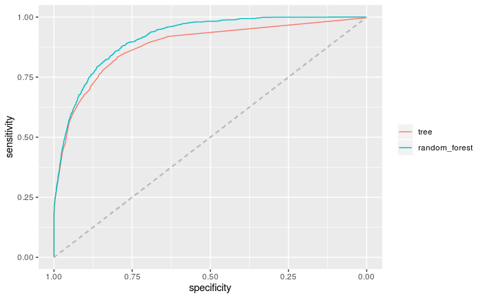

```r
ggroc(list(tree=tree_roc, random_forest=rf_roc)) +
  geom_segment(aes(x = 1, xend = 0, y = 0, yend = 1), color = "grey", linetype = "dashed") +
  theme(legend.title = element_blank())
```